# Practice 2 - Feature Selection using Genetic algorithms.

José Rodríguez Maldonado

January 2019

## Introduction

The idea of this practice is to analyze the application of genetic algorithm for the feature selection problem using a gene expression data set for the case of AML-ALL Leukemia disease. Is critical to distinguish ALL from AML in order to give a successful treatment.

## Part 1

**Apply a filter and a wrapper method for selection of features from the provided data set (Reuse your code from “Minería de datos”). Select 100-200 features from the Leukemia data set using the selected methods (for example correlation and SFS). We are going to use these subset of features for working with GAs.**

I have had some dificulty finding my old scripts, it’s a bit messy. So I will do it again. We will start loading the data. I have set the set the seed to 7, so the experiment can be repeated.

```r
# ensure the results are repeatable
set.seed(7)
library(RWeka)
test <- read.arff("ALL-AML_Leukemia 2/ALL-AML_test.arff")
train <- read.arff("ALL-AML_Leukemia 2/ALL-AML_train.arff")
```

### Filter

Once we have the data, we get into the filter method. The FSelector package will be used for this task. In order to select the features, a 3-step function was implemented.

- Create the formula
- Get the importance of the variables
- Select the 200 best ones

The different results obtained depend on the function used to evaluate the importance of the variables. I am going to use just 3 filter methods:

- **A chi-squared test**: is used to determine whether there is a significant difference between the expected frequencies and the observed frequencies in one or more categories.
- **Random forests**
- **Correlation**

```r
library(mlbench)
library(caret)
library(FSelector)

filter.Method <-function(data, num ) {

  # We use the mean decrease in accuracy to select the variables
  formula<-as.formula(paste("myclass",".",sep="~"))
  # Chi-squared
  weigths_chi<-chi.squared(formula, data)
  # Random.forest
  weigths_forest<-random.forest.importance(formula, data, importance.type = 1)
  # We get the variables that we want
  best_200_chi<-cutoff.k(weigths_chi, num)
  best_200_forest<-cutoff.k(weigths_forest, num)

  return(list(chi = best_200_chi, forest  = best_200_forest))
}

corr<-function(data, num.feat, perc) {

  m<-cor(data[,1:ncol(data)-1])
  corr.variab <- findCorrelation(m, cutoff=perc)
  cutoff<-corr.variab[1:num.feat]
  imp.features<-sapply(cutoff, function(i) colnames(data)[i])
  return(imp.features)
}

# AS I was told, we will select the 200 best variables
res <- filter.Method(train, 200)
res.cor<-corr( train, 200, 0.75)
forest <- res$forest
chi <- res$chi
```

Once we have the result, we can check whether the results are similar or not. Just as easy as check if the variables were ordered in the same way with this methods.

```r
chi[1:10]==forest[1:10]
```

```
##  [1]  TRUE FALSE  TRUE FALSE FALSE FALSE FALSE FALSE FALSE FALSE
```

```r
chi[1:10]==res.cor[1:10]
```

```
##  [1] FALSE FALSE FALSE FALSE FALSE FALSE FALSE FALSE FALSE FALSE
```

We can see that only agree a few variables. I think that it can be very interesting to check the AUC that we have training the same model with the different formulas calculated above.

```r
library(pROC)
library(nnet)
library(FSelector)

CrossVal<-function(all.data, k, formula, label.extra) {

  auc.glm<-list()
  auc.nnet<-list()
  cf<-createFolds(all.data$myclass, k=k)

  for(i in 1:k) {
    test <-all.data[unlist(cf[i]),]
    train <-all.data[-unlist(cf[i]),]
    train$myclass <-as.factor(train$myclass)
    test$myclass <-as.factor(test$myclass)
    auc.glm<-c(auc.glm,get.models(formula, train, test, "log" )$auc);
    auc.nnet<-c(auc.nnet,get.models(formula, train, test, "nnet")$auc);
  }

  ## PLOT
  res <- c(as.numeric(unlist(auc.glm)),as.numeric(unlist(auc.nnet)))
  type <- c(rep("GLM", length(unlist(auc.glm))), rep("NNET", length(unlist(auc.nnet))))
  data <- data.frame(num=res, type = type)
  bp <- ggplot(data, aes(x=type, y=res)) +
  geom_boxplot(fill="gray")+
  labs(title=label.extra,x="GLM vs NNET", y = "AUC")
  bp + theme_classic()

  return(list(glm.mean=mean(unlist(auc.glm)), nnet.mean=mean(unlist(auc.nnet)), plot = bp))
}
all.data<-rbind(train,test)

rescrsw.chi<-CrossVal(all.data, k = 20, formula = as.simple.formula(paste(chi, collapse = "+"), "myclass"), label.extra = "CHI")
rescrsw.forest<-CrossVal(all.data,k =20, formula =as.simple.formula(paste(forest, collapse = "+"), "myclass"), label.extra = "FOREST")
rescrsw.corr<-CrossVal(all.data, k =20, formula =as.simple.formula(paste(res.cor, collapse = "+"), "myclass"), label.extra = "CORRELATION")
```

Hereunder, we can check the results obtained for the 20 cross validation.

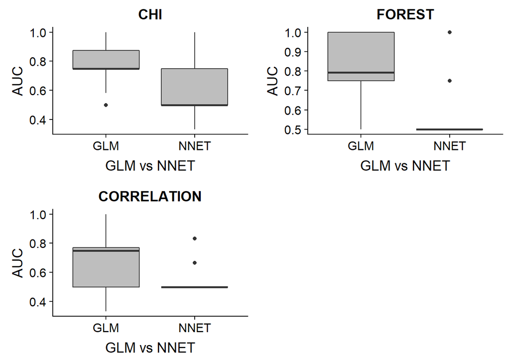

```r
library(ggplot2)
library(cowplot)
plot_grid(rescrsw.chi$plot, rescrsw.forest$plot, rescrsw.corr$plot )
```

We can easely see the differences in the results generated by different formulas. For the GLM model, we are having good results. In particular, we have slightly better results in the forest method. In contrast for the neural networks we have a clear underfitting. It may be caused by the lack of data that we have.

### Wrapper

Now, we are going to apply the wrapper methods. I am going to apply 2 of the wrapper methods that I used for “Mineria de datos”:

- Logistic regression
- Neural networks

I have decided to use this ones because they are faster than other methods like SVM.

```r
library(FSelector)
library(pROC)
library(nnet)

train$myclass <- as.factor(train$myclass)
test$myclass <- as.factor(test$myclass)

get.models <-function(formula, train, test, method ) {

  if(method == "log"){
    model<-glm(formula, train, family=binomial("logit"))
    estimation<-predict(model, newdata=test, type="response")
  }

  if(method == "nnet"){
    model<-nnet(formula,data=train, size=1, decay=0.2, maxit=3, trace=F)
    estimation<-predict(model, newdata=test, type="raw")
  }

  estimation<-round(estimation)

  roc<-roc(as.numeric(test$myclass), estimation, smooth=F, auc=T)

  auc <-roc$auc

  return(list(auc=auc,log=roc))
}

SW <- function(method, train, test) {

  cummulative.auc<-0
  variables <-colnames(train)[colnames(train) != "myclass"]

  for(level in 1:length(variables)) {
    best.auc<-0
    for(var in variables) {
      if(level==1){
        att<-var
      }else{
        att<-c(var, cummulative.list)
      }
      formula <-as.simple.formula(att,"myclass")
      new.auc<-get.models(formula, train, test, method)$auc[1];
      if(new.auc>best.auc) {
        best.auc<-new.auc
        best.vble<-var
      }
    }
    variables<-variables[variables != best.vble]

    if(level==1){
      cummulative.list<-best.vble
      cumm.auc<-best.auc
    }else{
      cummulative.auc<-c(cummulative.auc, best.auc)
      cummulative.list<-c(cummulative.list, best.vble)
      cumm.auc<-cummulative.auc[level-1]
    }

    if(length(cummulative.list)!=level || cumm.auc>best.auc[1] || length(cummulative.list)==100) break
  }

  best.formula<-as.simple.formula(cummulative.list,"myclass")

  return(list(variables=cummulative.list, cummulative.auc=cummulative.auc, formula=best.formula))
}

sw.glm<-SW("log",train, test)
sw.nnet<-SW("nnet",train, test)
```

If you execute this code, you could notice a warning telling *glm.fit: fitted probabilities numerically 0 or 1 occurred*. No worries, what it means is exactly what it says. The warning message is telling you is that a perfect fit is possible within the parametrisation of the model:

A probability P(Y=1)=0 is fitted to cases where the observed Y = 0; and a probability P(Y=1)=1 is fitted to cases where the observed Y = 1.

When we apply those functions, we get the following formulas as results:

```r
sw.glm$formula
```

```
## myclass ~ attribute1685 + attribute412 + attribute1 + attribute3 +
##     attribute5 + attribute6 + attribute7 + attribute9 + attribute14 +
##     attribute10 + attribute19 + attribute26 + attribute43 + attribute52 +
##     attribute56 + attribute77 + attribute101 + attribute119 +
##     attribute231 + attribute162 + attribute366 + attribute466 +
##     attribute773 + attribute845 + attribute913 + attribute1123 +
##     attribute1984 + attribute4364
## <environment: 0x0000000018ff5828>
```

```r
sw.nnet$formula
```

```
## myclass ~ attribute2288 + attribute1126 + attribute349 + attribute334 +
##     attribute199 + attribute133 + attribute28 + attribute156 +
##     attribute81 + attribute173 + attribute415 + attribute569 +
##     attribute413 + attribute37 + attribute1347 + attribute246 +
##     attribute197 + attribute464 + attribute964 + attribute2346 +
##     attribute73
## <environment: 0x0000000018f6b6b8>
```

The first thing that strikes us is that we don’t have 100 variables, as we specify in the function. Well, that occurs because during the execution of the algorithm, we get to a point where we don’t have an increase in the accuracy, so the algorithm stops.

```r
res.cv.glm<-CrossVal(all.data, k = 20, formula = sw.glm$formula, label.extra = "WRAPPER GLM")
res.cv.nnet<-CrossVal(all.data,k =20, formula =sw.nnet$formula, label.extra = "WRAPPER NNET")
```

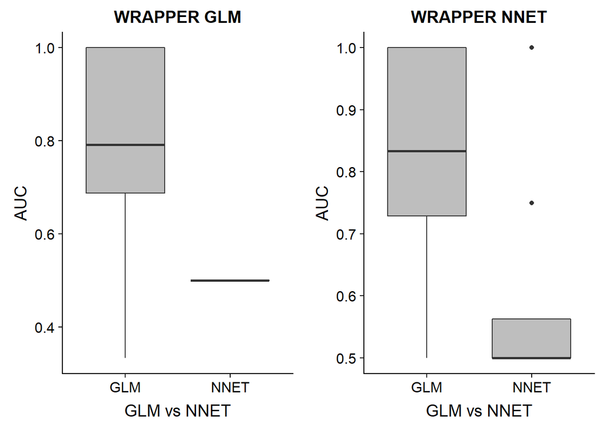

```r
library(cowplot)
plot_grid(res.cv.glm$plot, res.cv.nnet$plot )
```

As we saw before, here we can double check that neuronal networks are not working well in this problem. In case we want to use neural networks for this problem, we have to tune it or generate artificial data, in order to solve the underfitting problem. We can also appreciate a curious fact, in the graphs we get that glm algorithm throws better results with the formula provided by the NNET wrapper. It’s important to bring up that we got better results (in glm) for the wrapper methods than for the filter methods, as expected.

For the second part of the practice we are going to reuse the formulas obtained by the filter algorithms, because the wrapper formulas are not large enough.

## Part 2

**The idea of this part is to analyze the application of genetic algorithm for the feature selection problem using a gene expression data set for the case of AML-ALL Leukemia disease. In order to implement a Genetic algorithm, a prediction function is needed in order to evaluate the fitness function. Use a simple predictor function like LDA,QDA or logistic regression (each group will test one of the methods) (See Reference [P3-R5]). You can use the results of this work for compare with yours.**

My fitness function is the same as the one that we can find in pseudo code in the slides.

```r
library(GA)
library(MASS)
library(FSelector)
library(mclust)


fitness.penalty <- function(x) {
 x<-c(as.integer(paste(x, sep = ",")))
 result = -1
 x[length(x)] <- 0
 if (sum(x)> 1) {
   z <- lda(as.simple.formula(colnames(fit.data$train)[x==1], "myclass"), fit.data$train)
   Pr <- predict(z, fit.data$test)$class
   result=-classError(fit.data$test$myclass,Pr)$errorRate - 0.7*sum(x)/400
 }
 return(result)
}

fitness.no.penalty <- function(x) {
 x<-c(as.integer(paste(x, sep = ",")))
 result = -1
 x[length(x)] <- 0
 if (sum(x)> 1) {
   z <- lda(as.simple.formula(colnames(fit.data$train)[x==1], "myclass"), fit.data$train)
   Pr <- predict(z, fit.data$test)$class
   result=-classError(fit.data$test$myclass,Pr)$errorRate
 }
 return(result)
}

indices<-as.vector(rbinom(ncol(train), 1, 0.1))
indices1<-as.vector(rbinom(ncol(train), 1, 0.25))
indices2<-as.vector(rbinom(ncol(train), 1, 0.5))
indices3<-as.vector(rbinom(ncol(train), 1, 0.75))
indices4<-as.vector(rbinom(ncol(train), 1, 0.99))
debug(fitness.penalty)
fit1<-fitness.penalty(x = indices, fit.data)
fit2<-fitness.penalty(x = indices1, fit.data)
fit3<-fitness.penalty(x = indices2, fit.data)
fit4<-fitness.penalty(x = indices3, fit.data)
fit5<-fitness.penalty(x = indices4, fit.data)
```

Here I did some tests over the fitness function. Each chromosome has more ones than the previous one. The idea is to cover different options in order to ensure that the fitness function will work, no matter if chromosome given.

```r
cat("0.1% of ones ", fit1,"\n0.25% of ones", fit2,"\n0.5% of ones", fit3,"\n0.75% of ones", fit4,"\n0.99% of ones", fit5 )
```

```
## 0.1% of ones  -1.373132
## 0.25% of ones -3.311456
## 0.5% of ones -6.463206
## 0.75% of ones -9.677618
## 0.99% of ones -12.64737
```

**Use a filter and/or a wrapper method (Correlation/SFS) to reduce the number of input variables from 7129 to a number that permits you to run the GA algorithm.**

As I said before, I am going to use several filter methods.

```r
reduce<-function(variables, data){
  dat<-list()
  myclass<-data$train$myclass
  dat$train<-data$train[,res.cor]
  dat$train<-cbind(dat$train, myclass)
  myclass<-data$test$myclass
  dat$test<-data$test[,res.cor]
  dat$test<-cbind(dat$test, myclass)
  return(dat)
}
```

**Play with the parameters of the GA function to optimize operation of the genetic algorithm. Use a penalty term for reducing the number of features, and analyze that is indeed working.**

First of all, I think that it is very interesting to check the different results that we can get regarding the different formulas obtained before in the filter methods. We are going to use the function generated before to reduce the data set with and without penalty.

```r
fit.data<-list(train=train, test=test)
fit.data<-reduce(res.cor, fit.data)
GA.corr.no<-ga("binary", fitness= fitness.no.penalty,  pcrossover=0.8, pmutation=0.1, nBits = ncol(fit.data$train), monitor=FALSE, popSize = 30, maxiter = 180, parallel = TRUE)
fit.data<-reduce(chi, fit.data)
GA.chi.no<-ga("binary", fitness= fitness.no.penalty,  pcrossover=0.8, pmutation=0.1, nBits = ncol(fit.data$train), monitor=FALSE, popSize = 30, maxiter = 180, parallel = TRUE)
fit.data<-reduce(forest, fit.data)
GA.forest.no<-ga("binary", fitness= fitness.no.penalty,  pcrossover=0.8, pmutation=0.1, nBits = ncol(fit.data$train), monitor=FALSE, popSize = 30, maxiter = 180, parallel = TRUE)
```

```r
fit.data<-list(train=train, test=test)
fit.data<-reduce(res.cor, fit.data)
GA.corr<-ga("binary", fitness= fitness.penalty,  pcrossover=0.8, pmutation=0.1, nBits = ncol(fit.data$train), monitor=FALSE, popSize = 30, maxiter = 180, parallel = TRUE)
fit.data<-reduce(chi, fit.data)
GA.chi<-ga("binary", fitness= fitness.penalty,  pcrossover=0.8, pmutation=0.1, nBits = ncol(fit.data$train), monitor=FALSE, popSize = 30, maxiter = 180, parallel = TRUE)
fit.data<-reduce(forest, fit.data)
GA.forest<-ga("binary", fitness= fitness.penalty,  pcrossover=0.8, pmutation=0.1, nBits = ncol(fit.data$train), monitor=FALSE, popSize = 30, maxiter = 180, parallel = TRUE)
```

Here we have the result of applying the different formulas in the GA algorithm.

- Correlation
- Chi
- Forest

With penalty results:

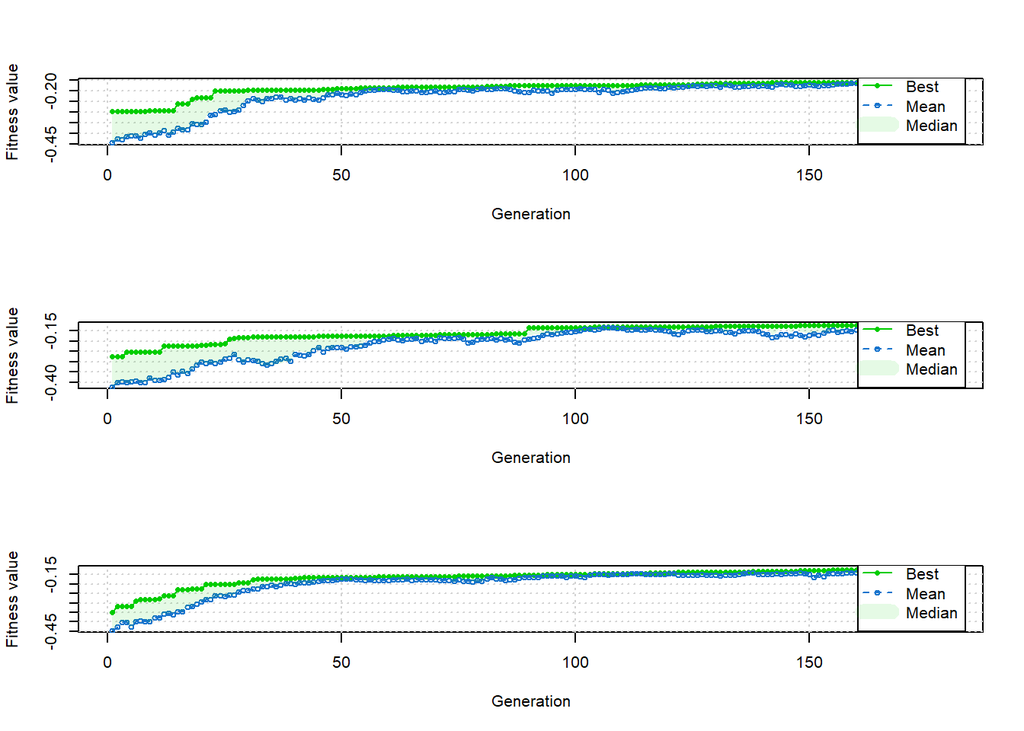

```r
par(mfrow=c(3,1))
plot(GA.corr)
plot(GA.chi)
plot(GA.forest)
```

Without penalty results:

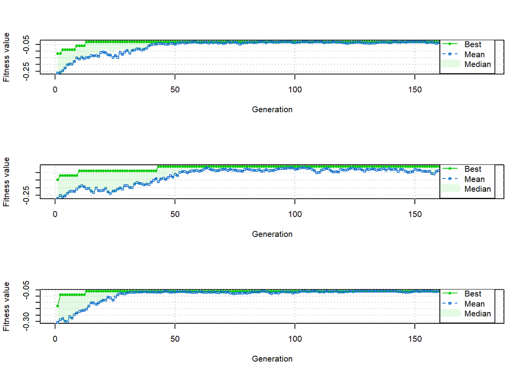

```r
par(mfrow=c(3,1))
plot(GA.corr.no)
plot(GA.chi.no)
plot(GA.forest.no)
```

As we can see, all the functions get to the best, I must mention that the forest formula throws better results. In terms of how long did it takes to get the best result. We can check out the summary of the results if we can see more information. It is also very interesting to se the fluctuation that we have in the results when we don’t apply the penalty.

```r
summary(GA.corr)
```

```
## -- Genetic Algorithm -------------------
##
## GA settings:
## Type                  =  binary
## Population size       =  30
## Number of generations =  180
## Elitism               =  2
## Crossover probability =  0.8
## Mutation probability  =  0.1
##
## GA results:
## Iterations             = 180
## Fitness function value = -0.1554118
## Solution =
##      x1 x2 x3 x4 x5 x6 x7 x8 x9 x10  ...  x200 x201
## [1,]  0  0  0  0  1  1  0  0  1   0          0    1
```

```r
summary(GA.chi)
```

```
## -- Genetic Algorithm -------------------
##
## GA settings:
## Type                  =  binary
## Population size       =  30
## Number of generations =  180
## Elitism               =  2
## Crossover probability =  0.8
## Mutation probability  =  0.1
##
## GA results:
## Iterations             = 180
## Fitness function value = -0.1225
## Solutions =
##      x1 x2 x3 x4 x5 x6 x7 x8 x9 x10  ...  x200 x201
## [1,]  0  1  0  0  0  1  0  1  1   0          1    1
## [2,]  0  1  0  0  0  1  0  1  1   0          1    0
## [3,]  0  1  0  0  0  1  0  1  1   0          1    0
## [4,]  0  1  0  0  0  1  0  1  1   0          1    0
```

```r
summary(GA.forest)
```

```
## -- Genetic Algorithm -------------------
##
## GA settings:
## Type                  =  binary
## Population size       =  30
## Number of generations =  180
## Elitism               =  2
## Crossover probability =  0.8
## Mutation probability  =  0.1
##
## GA results:
## Iterations             = 180
## Fitness function value = -0.119
## Solutions =
##      x1 x2 x3 x4 x5 x6 x7 x8 x9 x10  ...  x200 x201
## [1,]  0  0  1  0  0  1  0  0  0   0          0    0
## [2,]  0  0  1  0  0  1  0  0  0   0          0    0
```

We can see that, as we saw before the best result is for the forest formula. We can vary different parameters, I want to pay special attention to:

- **popSize**: Population size.
- **pcrossover**: Probability of crossover between two chrmosomes.
- **pmutation**: Probability of mutation in a parent chromosome.
- **elitism**: number of best fitness individuals to survive at each generation

As we know, parameters like popSize or elitism let us get to a better solutions much faster, as we can see below.

```r
fit.data<-reduce(forest, fit.data)
GA.forest.20<-ga("binary", fitness= fitness.penalty,  pcrossover=0.8, pmutation=0.1, nBits = ncol(fit.data$train), monitor=FALSE, popSize = 20, maxiter = 180, parallel = TRUE)
GA.forest.200<-ga("binary", fitness= fitness.penalty,  pcrossover=0.8, pmutation=0.1, nBits = ncol(fit.data$train), monitor=FALSE, popSize = 200, maxiter = 180, parallel = TRUE)
```

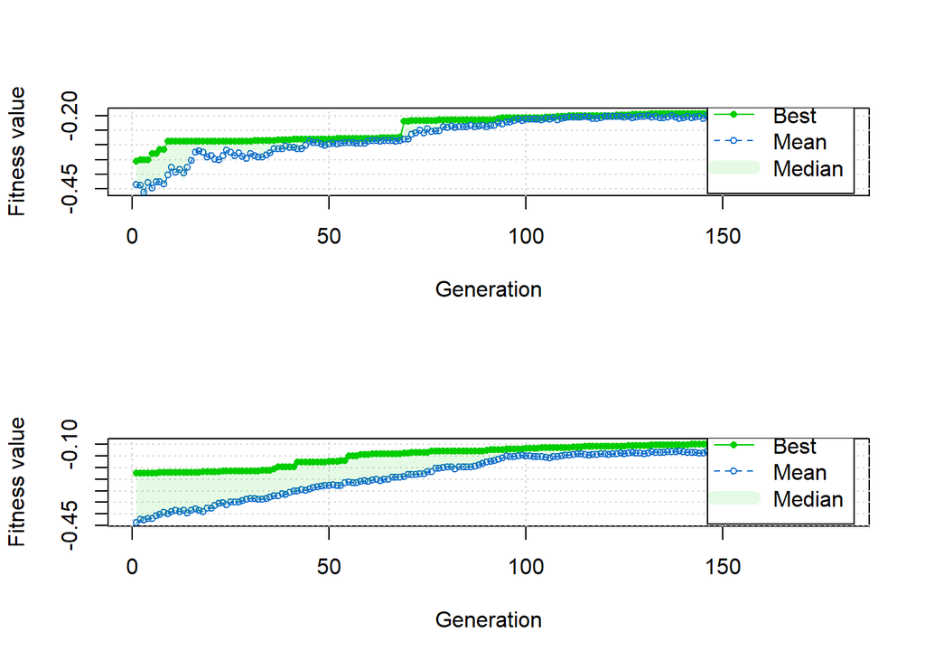

```r
par(mfrow=c(2,1))
plot(GA.forest.20)
plot(GA.forest.200)
```

```r
dataformulas <- c(res.cor, chi, forest)
pcrossover <- c(0.1,0.3,0.5,0.7,0.9)
pmutation <- c(0.1,0.3,0.5,0.7,0.9)


compute.iter <- function(pcross.list, pmutat.list, penalty = "YES", type="forest"){
valores <- c()
model <- c()
mut <- c()
cross<- c()

combit<- list(model = model, valores = valores, pmut = mut, pcross = cross)

if(type=="forest"){
  fit.data<-reduce(forest, fit.data)
}else if(type=="chi"){
  fit.data<-reduce(chi, fit.data)
}else{
  fit.data<-reduce(corr, fit.data)
}
  for (n in 1:length(pcross.list)) {
    for (m in 1:length(pmutat.list)) {
      if(penalty =="YES"){
    combit$model<- c(combit$model, ga("binary", fitness= fitness.penalty,  pcrossover=pcrossover[n], pmutation=pmutation[m], nBits = ncol(fit.data$train), monitor=FALSE, popSize = 20, maxiter = 50, parallel = TRUE))
      }else{
        combit$model<- c(combit$model, ga("binary", fitness= fitness.no.penalty,  pcrossover=pcrossover[n], pmutation=pmutation[m], nBits = ncol(fit.data$train), monitor=FALSE, popSize = 20, maxiter = 50, parallel = TRUE))
      }
      print(m)
      combit$pmut <- c(combit$pmut, pmutat.list[m])
      combit$pcross <- c(combit$pcross, pcross.list[n])
      combit$valores<- c(combit$valores, mean(plot(combit$model[[length(combit$model)]])$`mean`))
    }
  }

  return(combit)
}

res.yes.for <- compute.iter(pcrossover, pmutation, "YES", "forest")
res.yes.chi <- compute.iter(pcrossover, pmutation, "YES", "chi")
res.yes.cor <- compute.iter(pcrossover, pmutation, "YES", "corr")

res.no.for <- compute.iter(pcrossover, pmutation, "NO", "forest")
res.no.chi <- compute.iter(pcrossover, pmutation, "NO", "chi")
res.no.cor <- compute.iter(pcrossover, pmutation, "NO", "corr")
```

Once we have all the combination executed, we can analyze them.

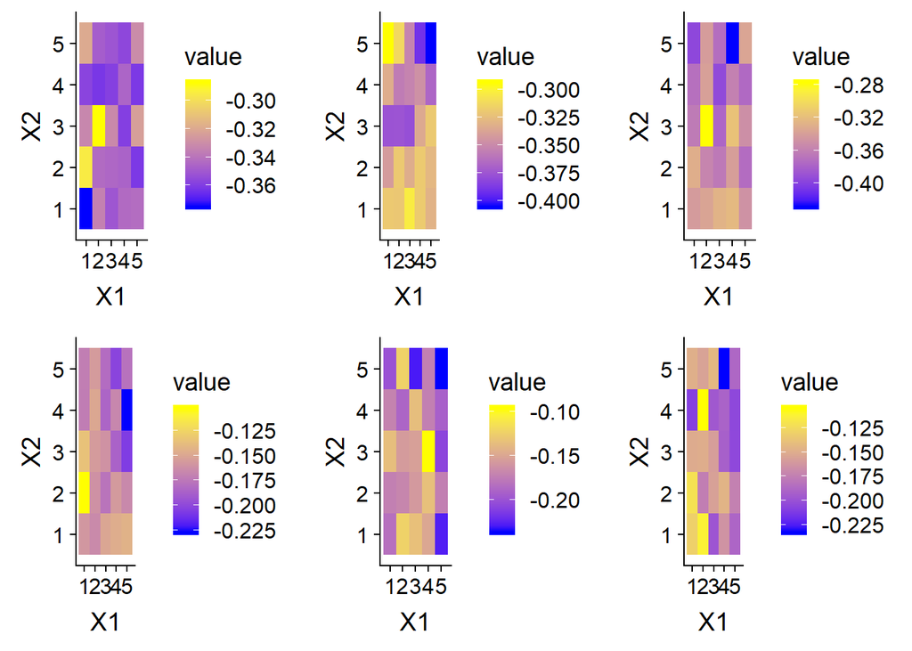

```r
library(ggplot2)
library(cowplot)
library(reshape)

p1<-ggplot(melt(matrix(res.yes.for$valores, ncol=5)), aes(X1, X2, fill = value)) + geom_tile() +
scale_fill_gradient(low = "blue",  high = "yellow")
p2<-ggplot(melt(matrix(res.yes.chi$valores, ncol=5)), aes(X1, X2, fill = value)) + geom_tile() +
scale_fill_gradient(low = "blue",  high = "yellow")
p3<-ggplot(melt(matrix(res.yes.cor$valores, ncol=5)), aes(X1, X2, fill = value)) + geom_tile() +
scale_fill_gradient(low = "blue",  high = "yellow")

p11<-ggplot(melt(matrix(res.no.for$valores, ncol=5)), aes(X1, X2, fill = value)) + geom_tile() +
scale_fill_gradient(low = "blue",  high = "yellow")
p12<-ggplot(melt(matrix(res.no.chi$valores, ncol=5)), aes(X1, X2, fill = value)) + geom_tile() +
scale_fill_gradient(low = "blue",  high = "yellow")
p13<-ggplot(melt(matrix(res.no.cor$valores, ncol=5)), aes(X1, X2, fill = value)) + geom_tile() +
scale_fill_gradient(low = "blue",  high = "yellow")

plot_grid(p1,p2,p3,p11,p12,p13,ncol = 3)
```

**Analyze different executions of the algorithms to see if the same variables are obtained in each run, or at least which are the most frequent ones.**

First of all, I need to get the different variables that were selected in the GA.

```r
model.2.data.frame<-function(matrix.model){
  df <- data.frame()
  for (i in 1:length(matrix.model$model)) {
    var<-summary(matrix.model$model[[i]])$solution
    df<-rbind(df, var)
  }
  return(df)
}

res.chromosome.for <- model.2.data.frame(res.yes.for)
res.chromosome.chi <- model.2.data.frame(res.yes.chi)
res.chromosome.cor <- model.2.data.frame(res.yes.cor)

res.chromosome.no.for <- model.2.data.frame(res.no.for)
res.chromosome.no.chi <- model.2.data.frame(res.no.chi)
res.chromosome.no.cor <- model.2.data.frame(res.no.cor)

df1 <- colSums(rbind(res.chromosome.for,res.chromosome.chi, res.chromosome.cor,res.chromosome.no.for, res.chromosome.no.chi, res.chromosome.no.cor ))


most.frequent.variables <- names(df1)[order(df1, decreasing=TRUE)][1:20]

most.frequent.variables
```

```
##  [1] "x39"  "x6"   "x35"  "x138" "x184" "x82"  "x87"  "x131" "x72"  "x61"
## [11] "x130" "x143" "x136" "x34"  "x75"  "x146" "x51"  "x199" "x194" "x137"
```

We can also do the same for the different formulas and check which is the most repeated variables in the same way.

Here we have the most repeated variables for the penalty fitness function over different combinations of pcrossover and pmutation.

```r
most.rep.for <- names(colSums(res.chromosome.for))[order(colSums(res.chromosome.for), decreasing=TRUE)][1:20]
most.rep.chi <- names(colSums(res.chromosome.chi))[order(colSums(res.chromosome.chi), decreasing=TRUE)][1:20]
most.rep.cor <- names(colSums(res.chromosome.cor))[order(colSums(res.chromosome.cor), decreasing=TRUE)][1:20]

most.rep.for
most.rep.chi
most.rep.cor



save(most.rep.chi, most.rep.cor, most.rep.for, file=".datos/rep-YES-penalty.RData")
```

```
##  [1] "x101" "x16"  "x23"  "x130" "x138" "x89"  "x115" "x131" "x153" "x175"
## [11] "x184" "x187" "x194" "x4"   "x6"   "x46"  "x74"  "x87"  "x91"  "x96"
```

```
##  [1] "x6"   "x201" "x39"  "x117" "x30"  "x47"  "x66"  "x111" "x144" "x151"
## [11] "x176" "x7"   "x22"  "x41"  "x73"  "x76"  "x81"  "x106" "x130" "x141"
```

```
##  [1] "x196" "x6"   "x58"  "x184" "x141" "x176" "x8"   "x23"  "x32"  "x61"
## [11] "x81"  "x194" "x10"  "x51"  "x65"  "x93"  "x100" "x131" "x136" "x137"
```

[output not shown]

And finally, the most repeated variables for the non penalty fitness function over different combinations of pcrossover and pmutation

```r
most.rep.no.for <- names(colSums(res.chromosome.no.for))[order(colSums(res.chromosome.no.for), decreasing=TRUE)][1:20]
most.rep.no.chi <- names(colSums(res.chromosome.no.chi))[order(colSums(res.chromosome.no.chi), decreasing=TRUE)][1:20]
most.rep.no.cor <- names(colSums(res.chromosome.no.cor))[order(colSums(res.chromosome.no.cor), decreasing=TRUE)][1:20]

most.rep.no.for
most.rep.no.chi
most.rep.no.cor



save(most.rep.no.for, most.rep.no.chi, most.rep.no.cor, file=".datos/rep-NO-penalty.RData")
```

```
##  [1] "x39"  "x138" "x72"  "x87"  "x131" "x35"  "x190" "x183" "x184" "x41"
## [11] "x189" "x6"   "x186" "x1"   "x67"  "x102" "x152" "x20"  "x37"  "x83"
```

```
##  [1] "x143" "x77"  "x75"  "x182" "x51"  "x110" "x111" "x136" "x35"  "x54"
## [11] "x63"  "x82"  "x154" "x22"  "x107" "x109" "x62"  "x191" "x194" "x12"
```

```
##  [1] "x6"   "x39"  "x82"  "x5"   "x35"  "x34"  "x172" "x72"  "x146" "x164"
## [11] "x9"   "x51"  "x61"  "x148" "x167" "x176" "x182" "x23"  "x50"  "x89"
```

[output not shown]

We can find big differences between all the results obtained. I have decided to check the general variables obtained in order to see the repeated variables that we have. In this case, I can just tell that the variables show in the general results are the ones that optimizes the result for the GA algorithm. It is very interesting to see this difference along the different formulas.